# Cognitive classification in HRS Core: Learning from HCAP

Rich Jones and Doug Tommet for HRS/HCAP Working Group

2026-10-22

## Contents

- Problem and goal
- Previous work: the Core algorithm
- The profile mixture model (PMM)
- Results and comparison

## Problem/question/goal

- Improve Core cognitive classification (e.g., Langa-Weir) using information extracted from HRS/HCAP (possibly measurement and/or prediction models)
- End goal: Cognitive classification, and classification probabilities

## Previous work: the Core algorithm

The Core algorithm (Analysis A7) exports the HRS/HCAP Algorithm (Manly et al., 2022) to the Core interview with a single domain of general cognitive performance. A factor score from the 8 Core cognitive tests is converted to a demographically adjusted T score, normed in the HCAP robust norms group and rounded to an integer. Two cut points on that score (39 and 48) and a self-rated memory rule (D102) define Normal, MCI, and Dementia; respondents with no test score are classified from the Jorm IQCODE (cut points 3.0 and 3.4). The cut points were selected by a rule fixed before any result was seen: match the weighted HRS/HCAP Algorithm dementia and MCI shares, then take the highest weighted dementia kappa.

In HRS/HCAP, survey-weighted agreement of the Core algorithm with the HRS/HCAP Algorithm is $\kappa_w$ = 0.50 for Normal, MCI, and Dementia, and $\kappa$ = 0.34 for dementia versus no dementia.

The Core algorithm gives each respondent a class. We wanted a probability of each class at the individual level.

## New approach: profile mixture modeling

- PMM is a mixture-modeling approach that uses the joint pattern of multiple observed indicators to define latent profiles and estimate the probability that each person belongs to each profile.
- In this project, PMM is trained against known HRS/HCAP actuarial classifications, with cognitive indicators adjusted using fixed parameters from the robust norms group, and then applied to HRS Core as a probabilistic classification rule.

## PMM structure

[figure not shown]

The PMM has 2 parts. The cognition model applies to the 3,283 HRS/HCAP participants with at least 1 cognitive test score or a self-rating of memory. The informant model applies to the 213 participants with an informant report (Jorm IQCODE) and no test score or self-rating; its only indicator is the IQCODE. Each participant receives probabilities from 1 model (N = 3,496).

`cg` is a latent class variable (a known class in the HRS/HCAP calibration sample, and an unknown class in the HRS Core application sample). The classes correspond to normal cognition, MCI/CIND, and dementia.

`GCP` (general cognitive performance) is a factor measured by the 8 cognitive tests. Its mean and variance differ by class (Normal class: mean 0, variance 1). The loadings, intercepts, thresholds, and residual variances of the tests are equal across classes, so the tests inform class only through GCP. The thresholds of self-rated memory differ by class.

`K` is a matrix of fixed regression coefficients used to adjust the tests for sociodemographics. These parameters are estimated in the robust norms sample and then loaded into the classification model: 8 tests $\times$ 24 sociodemographic terms = 192 coefficients. This fixed-parameter regression is equivalent to the approach used by Manly et al (2022) (regression adjustment of cognitive domains using the normative reference group).

Cognitive tests: `vdori`, Orientation to date; `vdlfl1z`, Animal naming; `vdlfl2`, Object naming; `vdlfl3`, President & vice-president; `vdwddelz`, Delayed word recall; `vdexf7z`, Number series; `vdsevens`, Serial sevens; `vdcount`, Count backwards from 20.

## Why a general cognitive factor

- Within each class, people differ in overall cognitive performance, so their test scores correlate. In the robust norms group, the continuous test scores correlate after demographic adjustment.
- A model without the factor sets these within-class correlations to 0. It counts correlated evidence as if it were independent (a low delayed recall score and a low animal naming score each count fully toward impairment), and its probabilities are more extreme than the data justify.
- The factor carries the within-class correlation with 1 set of loadings. The model with the factor fit the data better than the model without it, with fewer parameters.
- An exploratory comparison allowed test intercepts and thresholds to differ by class. That alternative was not adopted. The archived comparison includes a flagged fit and does not rule out the alternative.

## Same inputs as the Core algorithm

- The PMM uses the information the Core algorithm uses, so that differences in agreement with the HRS/HCAP Algorithm reflect the classification method and not access to different data.
- Not included: limitations in activities of daily living (ADL) and instrumental activities of daily living (IADL). The Core items do not say why a limitation is present, and a limitation with a physical cause would raise the probability of dementia (for example, hip arthritis and difficulty dressing).
- Not included: immediate word recall. It adds little beyond delayed recall (Jones et al., 2024) and is not part of the Core algorithm.

## How our approach differs from LDA and QDA

LDA and QDA (Linear and quadratic discriminant analysis, respectively) classify people from the joint distribution of multiple indicators, but they are usually framed for continuous Gaussian variables. In LDA, classes differ in their means, but they are assumed to share the same covariance matrix. In QDA, both the class means and the class-specific covariance matrices are allowed to differ. Our PMM is closer to a generative LDA/QDA family model than to a simple discriminative classifier, because it models the distribution of the indicators within class and then computes posterior class probabilities.

For the cognitive indicators, PMM handles the indicator means through fixed sociodemographic adjustment terms estimated in the robust norms group, plus class differences in the mean and variance of the general cognitive factor. That means expected performance is anchored to the normative reference group rather than re-estimated in the target sample. Because the factor variance differs by class, the implied covariance of the tests also differs by class, a structured form of QDA; the residual variances of the tests are equal across classes. PMM is also more flexible than classical LDA or QDA because several indicators are ordinal or discrete, so class separation is represented through latent-response means, thresholds, and a shared factor rather than only through multivariate Gaussian means and variances on the observed score scale.

## How our approach differs from predictive modeling

Many predictive models are optimized to maximize classification accuracy in the sample at hand, even if that means learning direct associations of sociodemographics with class membership or relying on patterns that are difficult to transport or interpret. Our PMM is built for a different goal: it separates measurement from classification, anchors expected cognitive performance in a normative reference group, and then classifies people according to how their observed indicator pattern departs from that demographically adjusted expectation. In this sense the PMM approach is a measurement model rather than a prediction model.

## How our approach is similar to LDA and machine learning

- Unlike Manly et al (2022), there is no decision tree.
- The PMM takes as input the cognitive tests and self-rated memory (or an informant report), and outputs probabilities of class membership. LDA and machine learning classifiers would do the same.

## Covariate adjustment

[figure not shown]

How to handle covariate adjustment, in a way consistent with what we did in Manly et al (2022), requires new methodology for the PMM. In Manly et al (2022), we adjust observed (continuous) cognitive indicators for covariates in the robust norms group (panel a1). Then we include in future analyses using the target (overall) sample the residual of observed cognition and expected cognition given the regression models defined in the robust norms group (panels b3, c3, the *residual* approach).

Approximately equivalent approaches to handling expectations-given-covariates-in-robust-norms-group would be to use the robust norms group defined regression parameters as fixed parameters in the target sample (panels b1, c1, the *fixed parameter* approach) or to include computed expected scores for each person, each outcome variable (y) given covariates and regression parameters defined in the robust norms group, and use these as an *offset* (regress observed on expected with coefficient fixed at 1; panels b2, c2).

All three of these approaches will return equivalent relationships between an external variable (z; panels c1-c3) and the cognitive variable.

We chose the fixed regression parameter approach (b1, c1) rather than the residual approach, because both the residual approach and the offset approach do not translate well to the case where the outcomes (y’s) are categorical.

## Results: class probabilities, all HRS/HCAP participants

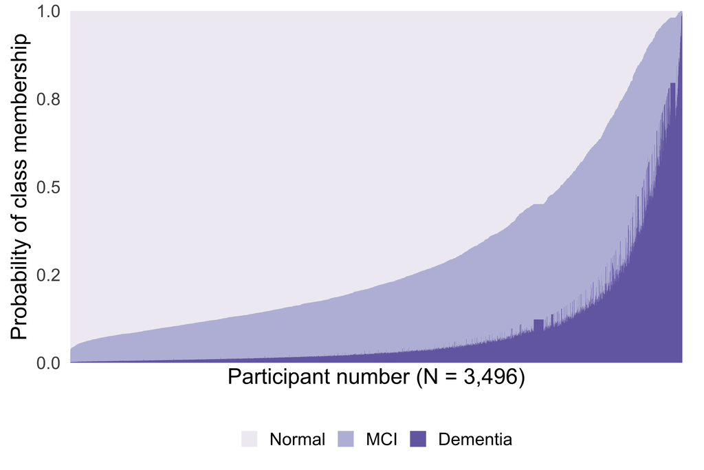

## PMM class probabilities

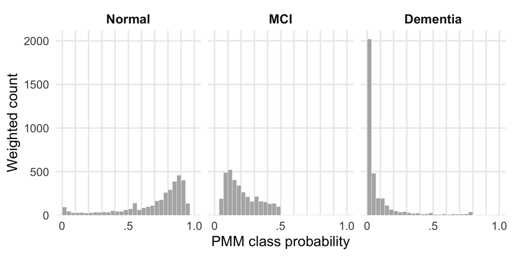

## PMM class membership

According to most likely class membership. This is the value that would be used to generate a “predicted” class label for each participant in the HRS/HCAP sample.

| Class | N | Weighted % |
| --- | --- | --- |
| Normal | 2,934 | 85.6 |
| MCI | 329 | 8.4 |
| Dementia | 233 | 6.0 |

Note: N and weighted percentages are computed in the non-replicated HRS/HCAP sample (N = 3,496). Weighted percentages use HCAP16WGTR. PMM probabilities and most likely class assignments use the cognition model, or the informant model when an IQCODE is present.

By way of comparison (survey-weighted, all 3,496 HRS/HCAP participants): the HRS/HCAP Algorithm classifies 69.4%, 21.4%, and 9.2% as Normal, MCI, and Dementia; the PMM probabilities average to 69.7%, 21.2%, and 9.1%; and Langa-Weir classifies 74.9%, 17.3%, and 7.9%. Manly et al. (2022) report 68%, 22%, and 10% for the HRS/HCAP Algorithm (weighted, class assignments based on Bayesian plausible values for cognition scores).

## Normal, MCI, Dementia (3-way) Agreement Matrix

Pairwise quadratic weighted kappa matrix using consensus-panel weights for consensus comparisons and HCAP weights otherwise

| Consensus sample | Consensus diagnosis | Manly-Jones algorithm | Langa-Weir | PMM |
| --- | --- | --- | --- | --- |
| Consensus diagnosis | 1.000 | 0.728 | 0.099 | 0.139 |
| Manly-Jones algorithm | 0.728 | 1.000 | 0.510 | 0.373 |
| Langa-Weir | 0.099 | 0.510 | 1.000 | 0.433 |
| PMM | 0.139 | 0.373 | 0.433 | 1.000 |

Note: This matrix combines pairwise quadratic weighted kappas computed under different weighting schemes. Entries involving the consensus diagnosis use consensus-sample weights HCAP16WGTR * samplingP^(-1), normalized within the validation subsample. Entries not involving the consensus diagnosis use HCAP population weights HCAP16WGTR. PMM entries use direct probability allocation with the corresponding survey weights; no replicated records.

## Dementia vs. Non-Dementia (2-way) Agreement Matrix

Pairwise kappa matrix for dementia versus non-dementia using consensus-panel weights for consensus comparisons and HCAP weights otherwise

| Consensus sample | Consensus diagnosis | Manly-Jones algorithm | Langa-Weir | PMM |
| --- | --- | --- | --- | --- |
| Consensus diagnosis | 1.000 | 0.538 | 0.736 | 0.261 |
| Manly-Jones algorithm | 0.538 | 1.000 | 0.407 | 0.308 |
| Langa-Weir | 0.736 | 0.407 | 1.000 | 0.358 |
| PMM | 0.261 | 0.308 | 0.358 | 1.000 |

Note: This matrix combines pairwise kappas for dementia versus non-dementia computed under different weighting schemes. Entries involving the consensus diagnosis use consensus-sample weights HCAP16WGTR * samplingP^(-1), normalized within the validation subsample. Entries not involving the consensus diagnosis use HCAP population weights HCAP16WGTR. PMM entries use direct probability allocation with the corresponding survey weights; no replicated records.

## Conclusion

Table 1

|  | HRS/HCAP Algorithm 3-class | HRS/HCAP Algorithm Dementia | Consensus panel (n = 50) 3-class | Consensus panel (n = 50) Dementia |
| --- | --- | --- | --- | --- |
| PMM | 0.37 | 0.31 | 0.14 | 0.26 |
| Core algorithm | 0.50 | 0.34 | 0.08 | 0.15 |
| Langa-Weir | 0.51 | 0.41 | 0.10 | 0.74 |

Survey-weighted kappas (3-class: quadratic weighted). HCAP weights; consensus-panel weights for the consensus comparisons.

- Agreement with the HRS/HCAP Algorithm: the highest 3-class kappa is for Langa-Weir, and the highest dementia kappa is for Langa-Weir. PMM 0.37 and 0.31; Core algorithm 0.50 and 0.34; Langa-Weir 0.51 and 0.41.
- Class shares: the PMM probabilities average to 69.7%, 21.2%, and 9.1% (HRS/HCAP Algorithm 69.4%, 21.4%, and 9.2%). Assigning each participant to the most likely class gives 85.6%, 8.4%, and 6.0%, which undercounts MCI. The probabilities, not the assigned classes, carry the PMM’s information.
- The consensus comparisons rest on 50 participants, so those kappas are imprecise.
- All agreement is in-sample: the PMM was calibrated, and the Core algorithm’s cut points were selected, in the same HRS/HCAP sample. Both are likely optimistic.

## Next steps

1. Manuscript (Analysis A2): Core algorithm, PMM, Langa-Weir, and Hudomiet compared with the HRS/HCAP Algorithm.
2. Cross-validated agreement for both the PMM and the Core algorithm.
3. PMM probabilities for HRS Core 2016 to 2022 (Analysis A3_2) for prevalence and incidence.

## Resources

[Current reports (README)](https://github.com/dougtommet/HRS_cog_classification#readme)

[Github repository](https://github.com/dougtommet/HRS_cog_classification)